# ForSysXR Explore Report

Assessment of proposed scenario

[figure not shown]

## 1. Effect of input parameters on the ForSys land base

The map below was generated using the input parameters provided for the proposed scenario. The layers in the map can be toggled on and off to examine the spatial distribution of the priorities in relation to the lands available to for treatment by ownership and land use type.

[interactive chart not shown]

## 2. Effect of ForSys land base filters on the total area and priority available for treatment.

[output not shown]

## 3. Map of available lands

[interactive chart not shown]

## 4. Stands available for treatment given filters for availability and threshold

The figure below shows the stands considered for treatment in the ForSys run defined by the user.

[interactive chart not shown]

## 5. Priority available for treatment by land type (PAD-US)

The figure below represents the proportion of each objective per land use class. For obj_1 the proportions are as follows: Agriculture: 23.7%, Pine forest: 26.6%, Water/Urban: 27.2%, Eucalyptus: 22.5%. For obj_3 the proportions are as follows: Agriculture: 21.6%, Pine forest: 26.2%, Water/Urban: 29.5%, Eucalyptus: 22.7%

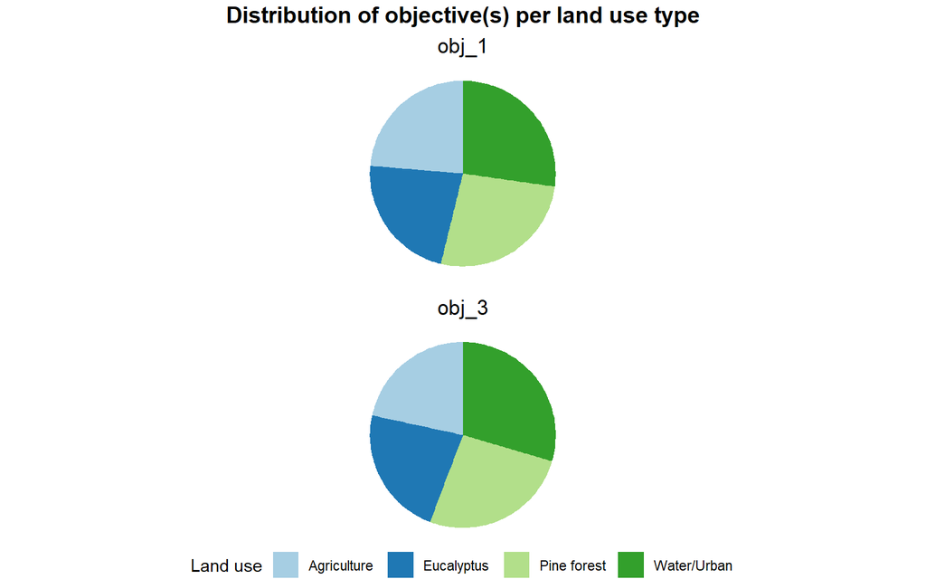

The figure below represents the proportion of each objective per land use class when considering only the stands that can be selected for treatment (i.e., after applying the several filters showed in Table 1). For obj_1 the proportions are as follows: Agriculture: 20.6%, Pine forest: 41.4%, Water/Urban: 25.9%, Eucalyptus: 12.1%. For obj_3 the proportions are as follows: Agriculture: 19.9%, Pine forest: 37.9%, Water/Urban: 23.9%, Eucalyptus: 18.4%

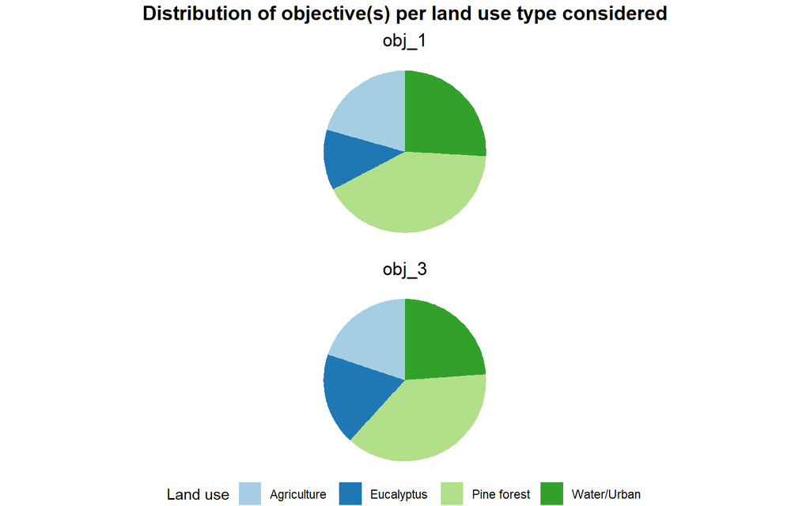

The figure below represents the proportion of each objective per land ownership class. For obj_1 the proportions are as follows: Public: 55.8%, County: 33%, Private: 11.1%. For obj_3 the proportions are as follows: Public: 50.6%, County: 17.3%, Private: 32%

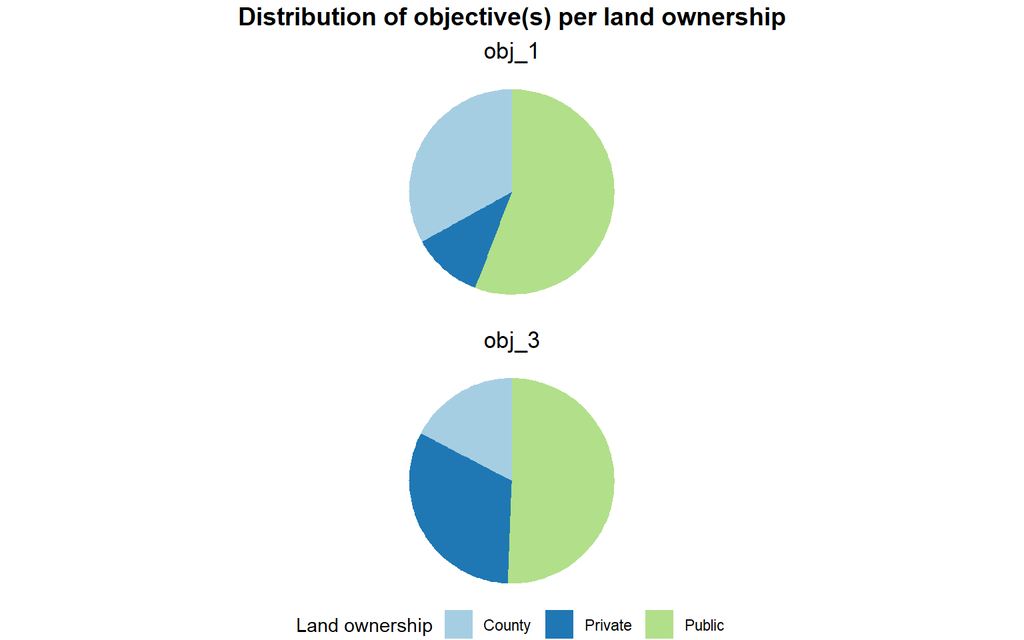

The figure below represents the proportion of each objective per land ownership class when considering only the stands that can be selected for treatment (i.e., after applying the several filters showed in Table 1). For obj_1 the proportions are as follows: Public: 100%, County: 0%, Private: 0%. For obj_3 the proportions are as follows: Public: 100%, County: 0%, Private: 0%

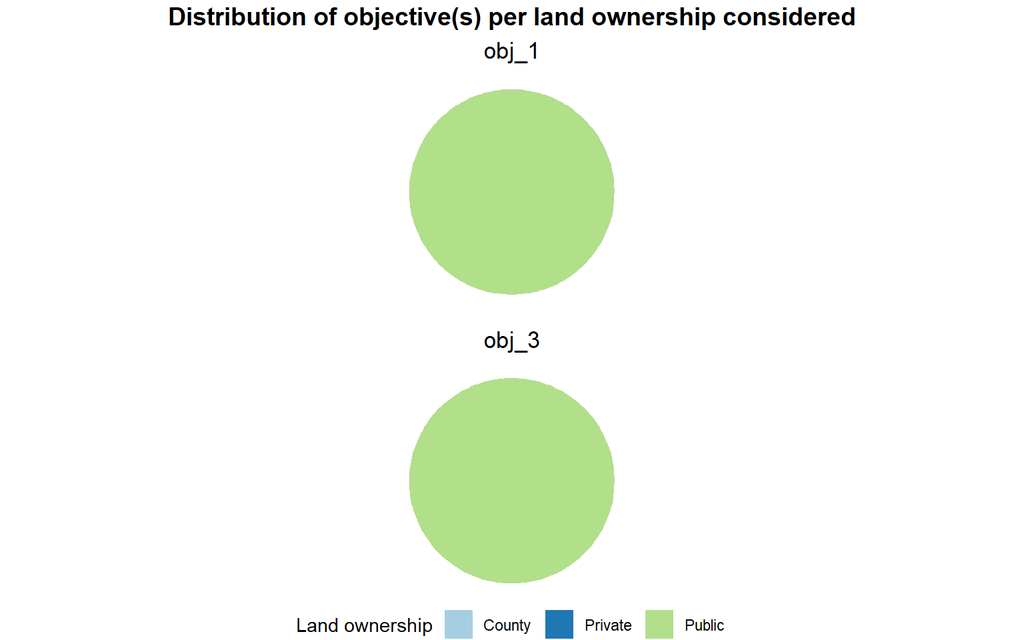

## Disclaimer and additional support

This report is automatically generated by ForSysXR and has not been validated. The figures and analysis shown here must be carefully analyzed and validated before drawing to conclusions. The USDA Forest Services are not responsible for the use and interpretation of any of the ForSys family products.

If you found any error or issue, please open a new issue [here](https://github.com/forsys-sp/ForSysXR/issues) and provide a replicable example of your data and run settings.

For further support please contact Michelle Day (michelle.day@usda.gov) or Alan Ager (alan.ager@oregonstate.edu)